# Final Project

Author

Jane Finocharo, Adriana Vance, and Ruining Zheng

Published

May 3, 2024

## Introduction

In 2021, approximately 10% of American households experienced food insecurity - a lack of access to enough food for a healthy, active life - at some point during the year (Rabbitt et al., n.d.). The percentage of people experiencing food insecurity varies significantly between counties, ranging from 2% to 26% (Hake, Engelhard, and Dewey 2023). Understanding the key predictors of food insecurity at the county level could help us target interventions and resources where they’re needed most and identify policies that are effective at reducing or preventing food insecurity.

In this project, we aim to predict the proportion of people in a county experiencing food insecurity using county-level data on sociodemographics, community characteristics, and food environment, as well as state-level data on Supplemental Nutrition Assistance Program (SNAP) policies. We will use lasso regression and random forest models to estimate food insecurity, the aim of which will be to use these past county characteristics to be able to predict food insecurity in the future. We will then use the results of these analyses to create a microsimulation model to assess the impact that policy and program participation changes could have on food insecurity.

## Data Sources

We compiled data from three different sources to identify the factors predicting rates of food insecurity at the county level in the United States:

- **County Health Rankings.** The County Health Rankings (CHR) provide annual data for hundreds of health-related indicators at the county level. We pulled our outcome measure - the proportion of people in the county experiencing food insecurity in 2021 - from the most recent data release (CHR 2024). We pulled data from the previous data release (CHR 2023) for several predictor variables in our model. These variables include sociodemographic and economic measures like race/ethnicity, income inequality, high school graduation rates, unemployment, and cost burden of housing and childcare; percent living in a rural area; and other environmental and community factors like air pollution, traffic volume, and access to exercise opportunities. We used previous research on the factors associated with food security at the individual and state level to select the CHR variables to include in our dataset [Bartfeld and Dunifon (2006)](Hunt et al. 2019)(Nicklett, Cheng, and Morris 2023).
- **USDA Food Environment Atlas**. The USDA Food Environment Atlas contains 280 indicators related to the food environment for each county in the U.S., including data on food access/availability, poverty, participation in nutrition benefits and programs, and sociodemographics. It includes data for multiple time points from 2010-2017.
- **SNAP Policy Datasets.** The USDA SNAP Policy Datasets contain detailed data on state-level SNAP policies, including broad-based categorical eligibility for SNAP benefits, recertification, waiver of face-to-face interviews for SNAP, eligibility restrictions on legal noncitizens’ receipt of SNAP, and treatment of vehicles as part of the SNAP asset test. We pulled data from 2010-2020.

## Set Up

### Load Libraries

```r
library(tidyverse)
library(here)
library(readxl)
library(tidyr)
library(lubridate)
library(DescTools)
library(tidymodels)
library(gridExtra)
library(vip)
library(glmnet)
library(patchwork)
```

### Loading, Cleaning and Merging Datasets

#### Accessing and Downloading Data

First, create a folder in your directory called “data”. Then follow the instructions below to access the datasets and save them with the correct names in the data folder:

Alternatively, our data can be accessed in the data folder on our github repository.

- **County Health Rankings 2024**: At [this link](https://www.countyhealthrankings.org/health-data/methodology-and-sources/data-documentation), click “2024 CHR CSV Analytic Data”. Rename file “CHR_2024.csv”

- **County Health Rankings 2023**: At [this link](https://www.countyhealthrankings.org/health-data/methodology-and-sources/data-documentation), click “2023 CHR CSV Analytic Data”. Rename file “CHR_2023.csv”

- **Food Environment Atlas**: At [this link](https://www.ers.usda.gov/data-products/food-environment-atlas/data-access-and-documentation-downloads/#Current%20Version), click “Food Environemnt Atlas .csv Files.” Open the .zip file, move “StateAndCountyData.csv” into data folder, rename “FEA.csv”. Move “SupplementalDataCounty.csv” into data folder, rename “FEA_supplement.csv”. Move “VariableList.csv” into the data folder.

- **SNAP Policy Data:** At [this link](https://www.ers.usda.gov/data-products/snap-policy-data-sets/), click “Snap Policy Database.” Move into data folder, rename “snap.xlsx”

#### Loading Data

The following code loads each of the datasets.

```r
# county health rankings
chr_col_names_2024 <- names(read_csv(here("data", "CHR_2024.csv"), n_max = 0))
chr_2024 <- read_csv(here("data", "CHR_2024.csv"), col_names = chr_col_names_2024, skip = 2)

chr_col_names_2023 <- names(read_csv(here("data", "CHR_2023.csv"), n_max = 0))
chr_2023 <- read_csv(here("data", "CHR_2023.csv"), col_names = chr_col_names_2023, skip = 2)

# food atlas + food atlas supplement
food_atlas <- read_csv(here("data", "FEA.csv"))
food_atlas_supplement <- read_csv(here("data", "FEA_supplement.csv"))
atlas_vars <- read_csv(here("data", "VariableList.csv"))

# SNAP policy data
snap <- read_excel(here("data", "snap.xlsx"), sheet = 2)
```

#### Tidying the Datasets for Merging

##### Food Atlas Dataframe

Here, we pivoted the data to be wider such that each unique county name formed a row. To do so, we used the FIPS codes which are unique identifiers of each county. After pivoting, we noticed there were state-level variables and duplicates of each county. We filtered out any county duplicates using stringr, and created a dataframe of unique state, county, and FIPS codes to join with the final dataset. The final dataset has 3,143 unique observations, which is the number of counties in the U.S.

```r
# Changing values from scientific notation, and rounding decimals to be shorter
food_atlas <- food_atlas %>%
  mutate(Value = format(Value, scientific = FALSE)) %>%
  mutate(Value = map_dbl(food_atlas$Value, round, digits = 4))

# Pivoting dataset to tidy - variables as columns and counties as rows

atlas_test <- food_atlas %>%
  pivot_wider(id_cols  = c(FIPS), # ID col is FIPS because of identical county names
              names_from = c(Variable_Code),
              values_from = Value) %>%
  filter(FIPS > 1000)

# There are two more variables than counties. The two observations here have NA values for all variables so will be filtered from the data
atlas_test %>%
  filter(is.na(atlas_test$LACCESS_POP10))

#Filtering here
atlas_test <- atlas_test %>%
  filter(FIPS != 2158 & FIPS != 46102)

# Create a tibble with unique state-county FIPS combos
strings <- c("County", "Total", "Parish", "city", "Borough", "Census Area", "Municipality")
fips_distinct <- food_atlas %>%
  group_by(FIPS) %>%
  select(State, County, FIPS) %>%
  distinct() %>%
  filter(!str_detect(County, pattern = paste(strings, collapse = "|")))

# Bind dataframes with data and county/state names

food_atlas <- full_join(fips_distinct, atlas_test)
```

##### SNAP Dataframe

Through looking at the documentation for the SNAP policy data, we learned that some variables were systematically missing. There were a few variables (transben, call_any, faceini, facerec, and the recertification variables) that had missing data for multiple years. Because the variables were missing not at random, we decided to remove them from our analysis. The rest of the variables were missing data from 2020, which is likely due to lack of data collection during the pandemic. NA observations were removed because imputation would likely not be able to reflect policy changes made during the pandemic.

After dealing with the missing values, we grouped the dataset by year and state, and took the mode of each observation. The data was categorical, so mode was used to capture the most frequent instance of each policy during each year.

```r
# Round the decimals to be the same pattern as above
snap <- snap %>%
  mutate_if(is.numeric, ~ round(., digits = 4)) %>%
  filter(yearmonth >= 201001) %>% # Only keep the data after year 2010. to assure that our analysis is closely connected to the current policies and circumstances.
  mutate(yearmonth = ym(yearmonth)) %>%
  mutate(year = year(yearmonth)) # Since the CHR data only contains year data, we also mutate a new column for year in SNAP.

snap_natest <- snap %>%
  select(-transben, -call_any, -faceini, -facerec, -(starts_with("cert"))) %>% # Removes variables with NA values for multiple years
  na.omit() # Removes any NA observations left, mostly in 2020 due to pandemic

# Function to change year-month observations into year observations, taking the most common value
#' Year-Month -> Year
#'
#' @param date # This is actually for the year of the dataset. Used to filter dataset from years 2010-2020
#' @param yearname # This is also the year, but must be written in quotes. Ex: yearname = "2016"
#'
#' @return # Returns a dataframe of a specific year of the SNAP data. Each observation is the mode of year-month observations in the original data.
#' @export
#'
#' @examples
#' snap_2010 <- rename_columns(date = 2010, yearname = "_2010")

rename_columns <- function(date, yearname){
  snap_date <- snap_natest %>%
    filter(year == date) %>%
    group_by(state_pc, year) %>%
    summarize_all(list(mode = ~Mode(.))) %>%
    select(-state_fips_mode, -statename_mode, -yearmonth_mode) %>%
    distinct(state_pc, .keep_all = TRUE)  # Keep only one row per state_pc

  names_date <- names(snap_date)
  new_date <- paste(names_date, yearname, sep = "")
  names(snap_date) <- new_date

  return(snap_date)
}
snap_2010 <- rename_columns(date = 2010, yearname = "_2010")
snap_2011 <- rename_columns(date = 2011, yearname = "_2011")
snap_2012 <- rename_columns(date = 2012, yearname = "_2012")
snap_2013 <- rename_columns(date = 2013, yearname = "_2013")
snap_2014 <- rename_columns(date = 2014, yearname = "_2014")
snap_2015 <- rename_columns(date = 2015, yearname = "_2015")
snap_2016 <- rename_columns(date = 2016, yearname = "_2016")
snap_2017 <- rename_columns(date = 2017, yearname = "_2017")
snap_2018 <- rename_columns(date = 2018, yearname = "_2018")
snap_2019 <- rename_columns(date = 2019, yearname = "_2019")
snap_2020 <- rename_columns(date = 2020, yearname = "_2020")

snap_year <- bind_cols(snap_2010,
                       snap_2011,
                       snap_2012,
                       snap_2013,
                       snap_2014,
                       snap_2015,
                       snap_2016,
                       snap_2017,
                       snap_2018,
                       snap_2019,
                       snap_2020) %>%
  rename(state = state_pc_2010) %>%
  group_by(state) %>%
  select(-starts_with("state_pc"),
         -starts_with("year"))
```

##### County Health Rankings

Here, we selected predictor variables from the CHR 2023 dataset and selected the food insecurity outcome measure from the CHR 2024 dataset. We used the 2023 dataset for our predictors to ensure that all predictor variables predated our outcome variable. We removed the rows for national and state-level data and kept data for counties.

```r
# selecting and renaming key variables. adding _chr at end so we know which variables came from CHR in merged dataset

chr_2023_small <-
  chr_2023 |>
  select(state_fips = 'State FIPS Code',
         county_fips = 'County FIPS Code',
         state = 'State Abbreviation',
         fips_5_digit = '5-digit FIPS Code',
         county = 'Name',
         food_env_index_chr = 'Food Environment Index raw value', # 2019
         exercise_access_chr = 'Access to Exercise Opportunities raw value', #2023, 2020, 2022
         child_poverty_chr = 'Children in Poverty raw value',
         income_inequality_chr = 'Income Inequality raw value',
         air_pollution_chr = 'Air Pollution - Particulate Matter raw value',
         limited_healthy_food_chr = 'Limited Access to Healthy Foods raw value',
         uninsured_adults_chr = 'Uninsured Adults raw value',
         uninsured_children_chr = 'Uninsured Children raw value',
         childcare_cost_burden_chr = 'Child Care Cost Burden raw value',
         traffic_volume_chr = 'Traffic Volume raw value',
         rural_chr = '% Rural raw value',
         hs_grad_rate_chr = 'High School Graduation raw value',
         life_expectancy_chr = 'Life Expectancy raw value',
         pct_under18_chr = '% Below 18 Years of Age raw value',
         housing_cost_burden_chr = 'Severe Housing Cost Burden raw value',
         residential_segregation_chr = 'Residential Segregation - Black/White raw value',
         pct_NH_Black_chr = '% Non-Hispanic Black raw value',
         pct_Hispanic_chr = '% Hispanic raw value',
         pct_NH_white_chr = '% Non-Hispanic White raw value',
         pct_not_english_prof_chr = '% Not Proficient in English raw value',
         unemployment_chr = 'Unemployment raw value') |>
  filter(county_fips!="000") |>
  mutate(
    fips = as.numeric(fips_5_digit)) |>
  select(!c(state_fips, county_fips, fips_5_digit)) |>
  mutate_if(is.numeric, ~ round(., digits = 4))



chr_2024_small <-
  chr_2024 |>
  select(state_fips = 'State FIPS Code',
         county_fips = 'County FIPS Code',
         state = 'State Abbreviation',
         fips_5_digit = '5-digit FIPS Code',
         county = 'Name',
         food_insecurity_chr = 'Food Insecurity raw value') |>
  filter(county_fips!="000") |>
  mutate(
    fips = as.numeric(fips_5_digit)) |>
  select(!c(state_fips, county_fips, fips_5_digit)) |>
  mutate_if(is.numeric, ~ round(., digits = 4))
```

#### Removing Inconsistent County Observations

We ran anti-join commands to check for counties in each dataset that were not present in the other dataset, and removed two counties from 2024 and one county from 2023 as a result. We then merged the two CHR datasets. In the next section, we will merge the combined CHR dataset with the food atlas data and the SNAP policy data. The following output are tibbles listing the counties that do not match between datasets. These are counties that were either changed or removed between data collection, so they will be removed.

```r
anti_join(chr_2024_small, chr_2023_small, by = "fips")
```

```
# A tibble: 2 × 4
  state county                   food_insecurity_chr  fips
  <chr> <chr>                                  <dbl> <dbl>
1 AK    Chugach Census Area                    0.084  2063
2 AK    Copper River Census Area               0.124  2066
```

```r
anti_join(chr_2023_small, chr_2024_small, by = "fips")
```

```
# A tibble: 1 × 24
  state county          food_env_index_chr exercise_access_chr child_poverty_chr
  <chr> <chr>                        <dbl>               <dbl>             <dbl>
1 AK    Valdez-Cordova…                7.7               0.724             0.122
# ℹ 19 more variables: income_inequality_chr <dbl>, air_pollution_chr <dbl>,
#   limited_healthy_food_chr <dbl>, uninsured_adults_chr <dbl>,
#   uninsured_children_chr <dbl>, childcare_cost_burden_chr <dbl>,
#   traffic_volume_chr <dbl>, rural_chr <dbl>, hs_grad_rate_chr <dbl>,
#   life_expectancy_chr <dbl>, pct_under18_chr <dbl>,
#   housing_cost_burden_chr <dbl>, residential_segregation_chr <dbl>,
#   pct_NH_Black_chr <dbl>, pct_Hispanic_chr <dbl>, pct_NH_white_chr <dbl>, …
```

Here, we filter out the counties.

```r
chr_2024_small <-
  chr_2024_small |>
  filter(fips !=2063,
         fips !=  2066)
chr_2023_small <-
  chr_2023_small |>
  filter(fips != 2261)
```

The following anti-joins show that there are no longer any county observations that do not match.

```r
anti_join(chr_2024_small, chr_2023_small, by = "fips")
```

```
# A tibble: 0 × 4
# ℹ 4 variables: state <chr>, county <chr>, food_insecurity_chr <dbl>,
#   fips <dbl>
```

```r
anti_join(chr_2023_small, chr_2024_small, by = "fips")
```

```
# A tibble: 0 × 24
# ℹ 24 variables: state <chr>, county <chr>, food_env_index_chr <dbl>,
#   exercise_access_chr <dbl>, child_poverty_chr <dbl>,
#   income_inequality_chr <dbl>, air_pollution_chr <dbl>,
#   limited_healthy_food_chr <dbl>, uninsured_adults_chr <dbl>,
#   uninsured_children_chr <dbl>, childcare_cost_burden_chr <dbl>,
#   traffic_volume_chr <dbl>, rural_chr <dbl>, hs_grad_rate_chr <dbl>,
#   life_expectancy_chr <dbl>, pct_under18_chr <dbl>, …
```

Here, we join the final County Health Rankings dataset.

```r
chr_small <-
  full_join(chr_2024_small, chr_2023_small, by = "fips")
```

#### Merging Data

The anti joins below show the counties in the food atlas dataset that are not represented in the CHR dataset, and vice versa. All of these counties were either changed or deleted in the time that these data were collected. In order to be able to merge our datasets, we will remove these counties from the data.

```r
# merging atlas and CHR
food_atlas <- food_atlas %>%
  rename(fips = FIPS)

anti_join(food_atlas, chr_small, by = "fips")
```

```
# A tibble: 4 × 335
# Groups:   fips [4]
  State County          fips LACCESS_POP10 LACCESS_POP15 PCH_LACCESS_POP_10_15
  <chr> <chr>          <dbl>         <dbl>         <dbl>                 <dbl>
1 AK    Valdez-Cordova  2261         2694.         5011.                 86.0
2 AK    Wade Hampton    2270         4955.         4615                  -6.86
3 SD    Shannon        46113         6478.        10780.                 66.4
4 VA    Bedford        51515          540.          540.                  0
# ℹ 329 more variables: PCT_LACCESS_POP10 <dbl>, PCT_LACCESS_POP15 <dbl>,
#   LACCESS_LOWI10 <dbl>, LACCESS_LOWI15 <dbl>, PCH_LACCESS_LOWI_10_15 <dbl>,
#   PCT_LACCESS_LOWI10 <dbl>, PCT_LACCESS_LOWI15 <dbl>, LACCESS_HHNV10 <dbl>,
#   LACCESS_HHNV15 <dbl>, PCH_LACCESS_HHNV_10_15 <dbl>,
#   PCT_LACCESS_HHNV10 <dbl>, PCT_LACCESS_HHNV15 <dbl>, LACCESS_SNAP15 <dbl>,
#   PCT_LACCESS_SNAP15 <dbl>, LACCESS_CHILD10 <dbl>, LACCESS_CHILD15 <dbl>,
#   LACCESS_CHILD_10_15 <dbl>, PCT_LACCESS_CHILD10 <dbl>, …
```

```r
anti_join(chr_small, food_atlas)
```

```
# A tibble: 2 × 27
  state.x county.x food_insecurity_chr  fips state.y county.y food_env_index_chr
  <chr>   <chr>                  <dbl> <dbl> <chr>   <chr>                 <dbl>
1 AK      Kusilva…               0.259  2158 AK      Kusilva…                 NA
2 SD      Oglala …               0.263 46102 SD      Oglala …                 NA
# ℹ 20 more variables: exercise_access_chr <dbl>, child_poverty_chr <dbl>,
#   income_inequality_chr <dbl>, air_pollution_chr <dbl>,
#   limited_healthy_food_chr <dbl>, uninsured_adults_chr <dbl>,
#   uninsured_children_chr <dbl>, childcare_cost_burden_chr <dbl>,
#   traffic_volume_chr <dbl>, rural_chr <dbl>, hs_grad_rate_chr <dbl>,
#   life_expectancy_chr <dbl>, pct_under18_chr <dbl>,
#   housing_cost_burden_chr <dbl>, residential_segregation_chr <dbl>, …
```

We removed the counties that are not present in both datasets, confirmed that the datasets now match, and then merged the food atlas and CHR data.

```r
food_atlas <- food_atlas %>%
  filter(fips != 2261,
         fips != 2270,
         fips != 46113,
         fips != 51515)
chr_small <- chr_small %>%
  filter(fips != 2158,
         fips != 46102)

# Checking that there are no other unmatched observations
anti_join(food_atlas, chr_small, by = "fips") # success!
```

```
# A tibble: 0 × 335
# Groups:   fips [0]
# ℹ 335 variables: State <chr>, County <chr>, fips <dbl>, LACCESS_POP10 <dbl>,
#   LACCESS_POP15 <dbl>, PCH_LACCESS_POP_10_15 <dbl>, PCT_LACCESS_POP10 <dbl>,
#   PCT_LACCESS_POP15 <dbl>, LACCESS_LOWI10 <dbl>, LACCESS_LOWI15 <dbl>,
#   PCH_LACCESS_LOWI_10_15 <dbl>, PCT_LACCESS_LOWI10 <dbl>,
#   PCT_LACCESS_LOWI15 <dbl>, LACCESS_HHNV10 <dbl>, LACCESS_HHNV15 <dbl>,
#   PCH_LACCESS_HHNV_10_15 <dbl>, PCT_LACCESS_HHNV10 <dbl>,
#   PCT_LACCESS_HHNV15 <dbl>, LACCESS_SNAP15 <dbl>, PCT_LACCESS_SNAP15 <dbl>, …
```

```r
anti_join(chr_small, food_atlas, by = "fips") # success!
```

```
# A tibble: 0 × 27
# ℹ 27 variables: state.x <chr>, county.x <chr>, food_insecurity_chr <dbl>,
#   fips <dbl>, state.y <chr>, county.y <chr>, food_env_index_chr <dbl>,
#   exercise_access_chr <dbl>, child_poverty_chr <dbl>,
#   income_inequality_chr <dbl>, air_pollution_chr <dbl>,
#   limited_healthy_food_chr <dbl>, uninsured_adults_chr <dbl>,
#   uninsured_children_chr <dbl>, childcare_cost_burden_chr <dbl>,
#   traffic_volume_chr <dbl>, rural_chr <dbl>, hs_grad_rate_chr <dbl>, …
```

Here, we join the Food Atlas and County Health Rankings datasets

```r
atlas_chr <- full_join(food_atlas, chr_small, by = "fips")
```

Next, we merged the combined food atlas/CHR data with the state-level SNAP data. We conducted a left join to map state level data onto each county. We then removed variables that directly indicate food security/insecurity, other than our outcome variable from CHR.

```r
snap_year <- snap_year %>%
  rename(State = state)

atlas_chr_snap <- left_join(atlas_chr, snap_year)

# We also would like to filter out variables that directly indicate food security/insecurity value in other data frames besides the CHR data.
atlas_chr_snap <- atlas_chr_snap %>%
  select(-contains(c("FOODSEC", "FOODINSEC")))
```

### Predictive Model

#### Problem Formulation

Our final dataset contains information about county and state-level characteristics that our research has shown may have an impact on food insecurity. We aim to create a model that can use these past characteristics to predict food insecurity levels in the future. As described above, our data spans multiple time periods and covers county characteristics related to both food access and socioeconomic status of counties. The characteristics in the data range from years 2010-2023, and will be used to predict the County Health Rankings food insecurity estimates from 2024.

#### Split Data into Training and Testing Data

By splitting our data into training and testing data, we will be able to see how our predictive model performs on unseen data. In the future, this would ideally be applied to a new data set of all counties with these characteristics, to predict food insecurity levels in proceeding years.

```r
set.seed(20240430)

split <- initial_split(data = atlas_chr_snap, prop = 0.75)

training <- training(split)
testing <- testing(split)
```

#### Exploratory Data Analysis

Exploratory data analysis will be important in understanding how our models can best perform. Informed by our research, our exploratory data analysis will allow us to further understand the potential relationships between certain variables in our dataset, and food insecurity levels.

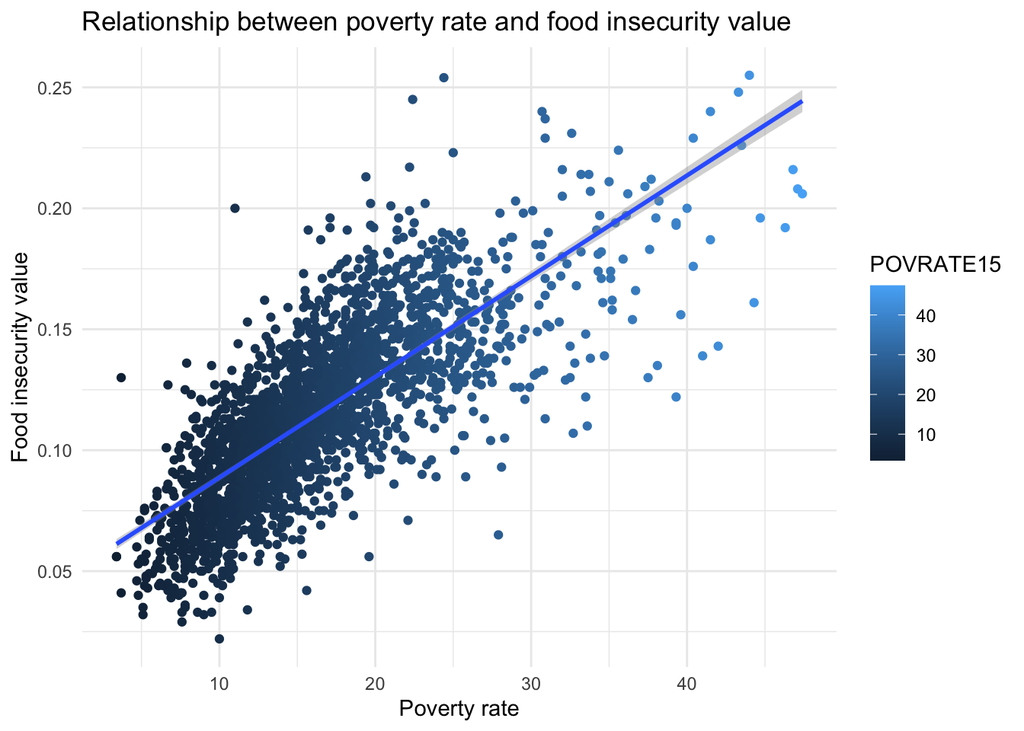

```r
training %>%
  ggplot(mapping = aes(x = POVRATE15, y = food_insecurity_chr, color = POVRATE15)) +
  geom_point() +
  geom_smooth(method = "lm", se = TRUE) +
  labs(title = "Relationship between poverty rate and food insecurity value",
       x = "Poverty rate",
       y = "Food insecurity value") +
  theme_minimal()
```

The line chart shows a general linear relationship between the poverty rate of each county and the food insecurity value. As the poverty rate increases, the food insecurity value also increases.

We also think the food security is closely connected to the programs and policies participants since the purposes of these benefits are to help people who are in danger of food insecurity due to various reasons. Thus, we selected the program participant proportional variables and observe the density distribution of them and of food security value.

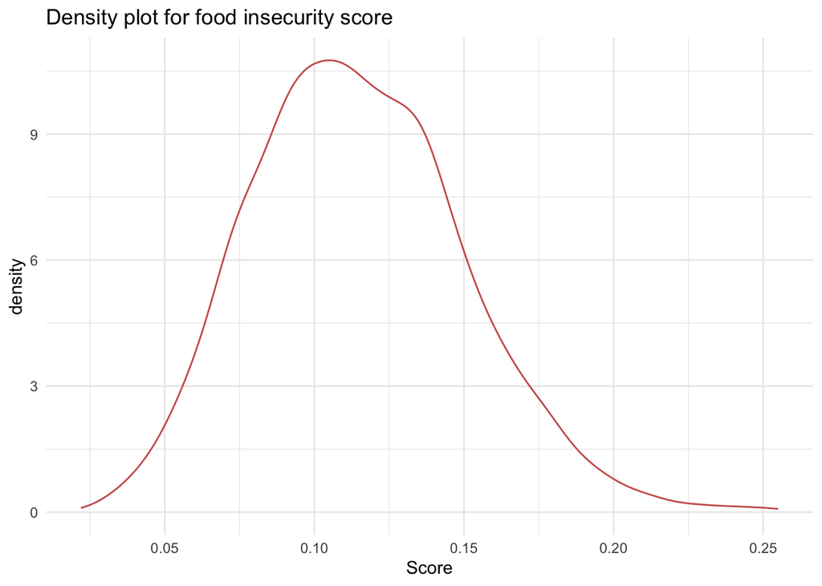

```r
# Select all program participants variables
program_participants <- training %>%
  select(
    fips,
    PCT_SNAP17,
    PCT_NSLP17,
    PCT_SBP17,
    PCT_SFSP17,
    PCT_WIC17,
    PCT_WICINFANTCHILD16,
    PCT_WICWOMEN16,
    food_insecurity_chr
  )

# Density distribution of food insecurity value among all observations
program_participants %>%
  ggplot() +
  geom_density(mapping = aes(x = food_insecurity_chr), color = "indianred") +
  labs(title = "Density plot for food insecurity score",
       x = "Score") +
  theme_minimal()
```

The density plot for our dependent variable, the food insecurity value, shows a close to normal distributed bell shape. 0.11 is most common score for the counties with a high density, or high relative probability.

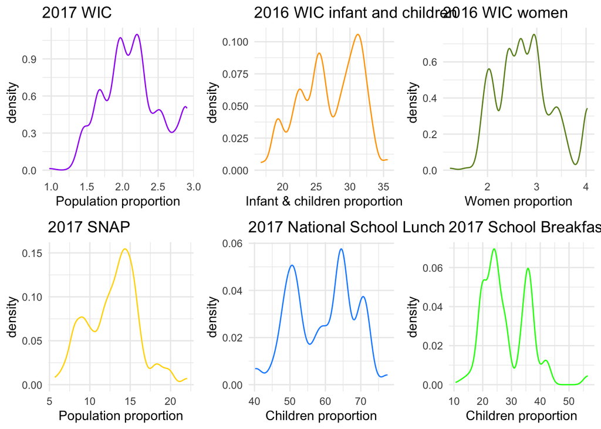

```r
# Density distribution of program participant proportions among all observations

p1 <- program_participants %>%
  ggplot() +
  geom_density(mapping = aes(x = PCT_WIC17), color = "purple") +
  labs(title = "2017 WIC",
       x = "Population proportion") +
  theme_minimal()

p2 <- program_participants %>%
  ggplot() +
  geom_density(mapping = aes(x = PCT_WICINFANTCHILD16), color = "orange") +
  labs(title = "2016 WIC infant and children",
       x = "Infant & children proportion") +
  theme_minimal()

p3 <- program_participants %>%
  ggplot() +
  geom_density(mapping = aes(x = PCT_WICWOMEN16), color = "olivedrab") +
  labs(title = "2016 WIC women",
       x = "Women proportion") +
  theme_minimal()

p4 <- program_participants %>%
  ggplot() +
  geom_density(mapping = aes(x = PCT_SNAP17), color = "gold") +
  labs(title = "2017 SNAP",
       x = "Population proportion") +
  theme_minimal()

p5 <- program_participants %>%
  ggplot() +
  geom_density(mapping = aes(x = PCT_NSLP17), color = "dodgerblue") +
  labs(title = "2017 National School Lunch",
       x = "Children proportion") +
  theme_minimal()

p6 <- program_participants %>%
  ggplot() +
  geom_density(mapping = aes(x = PCT_SBP17), color = "green") +
  labs(title = "2017 School Breakfast",
       x = "Children proportion") +
  theme_minimal()

grid.arrange(p1, p2, p3, p4, p5, p6, ncol = 3)
```

Compared to other programs, the WIC program has a relatively lower proportion of participants. All six density plots are not showing similar distribution patterns.

The density distribution of the program participation proportions do not show the similar trends as we expected before, so we will do the correlation test to determine whether these variables will be included as predictors.

#### Feature Selection

Here, we perform feature selection before our model specification to narrow down the number of predictors we will be using. Firstly, we measure the correlation between our variable of interest–food insecurity– and our other variables. After, we filter out any variables that have a correlation of 0 with our food insecurity

By doing this, we narrow down the number of predictors into about 350 variables instead of 604 variables in the original training data.

```r
correlation <- training %>%
  select(where(is.numeric)) %>%
  cor()

# Only keep variables have correlation with the food insecurity variable.
correlation_df <- as.data.frame(correlation) %>%
  select(food_insecurity_chr) %>%
  filter(food_insecurity_chr != 0) %>% # filter out those correlations equal 0
  rownames_to_column() %>%
  pivot_wider(
    names_from = rowname,
    values_from = food_insecurity_chr
  )

# Intersect correlation data frame with training data, so only variables show in both data frame will be left.
selected_variables <- intersect(names(correlation_df), names(training))

# Filter out variables that are not in intersection results as the last step assigned to
sub_training <- training[selected_variables]
```

#### Visualizing Correlations

Here, we are visualizing the relationship between our food insecurity measure, and some of the predictors chosen in our correlation test. Below are scatter plots of these variables, with smoothed lines representing the linear relationship.

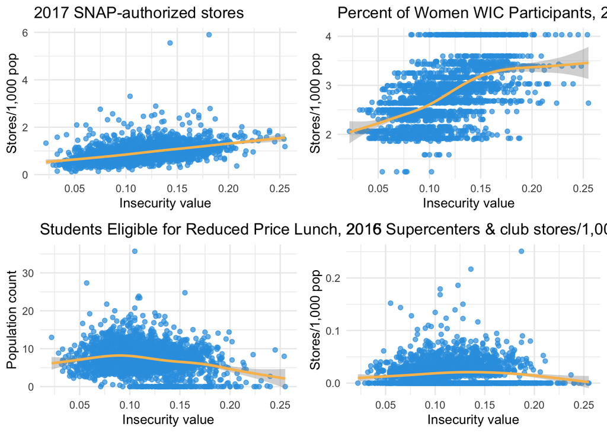

```r
c1 <- training %>%
  ggplot(mapping = aes(x = food_insecurity_chr, y = SNAPSPTH17)) +
  geom_point(alpha = 0.7, color = "#2FA0E2") +
  geom_smooth(color = "#F8BE5B") +
  labs(title = "2017 SNAP-authorized stores",
       x = "Insecurity value",
       y = "Stores/1,000 pop") +
  theme_minimal()

c2 <- training %>%
  ggplot(mapping = aes(x = food_insecurity_chr, y = PCT_WICWOMEN16)) +
  geom_point(alpha = 0.7, color = "#2FA0E2") +
  geom_smooth(color = "#F8BE5B") +
  labs(title = "Percent of Women WIC Participants, 2016",
       x = "Insecurity value",
       y = "Stores/1,000 pop") +
  theme_minimal()

c3 <- training %>%
  ggplot(mapping = aes(x = food_insecurity_chr, y = PCT_REDUCED_LUNCH15)) +
  geom_point(alpha = 0.7, color = "#2FA0E2") +
  geom_smooth(color = "#F8BE5B") +
  labs(title = "Students Eligible for Reduced Price Lunch, 2015",
       x = "Insecurity value",
       y = "Population count") +
  theme_minimal()

c5 <- training %>%
  ggplot(mapping = aes(x = food_insecurity_chr, y = SUPERCPTH16)) +
  geom_point(alpha = 0.7, color = "#2FA0E2") +
  geom_smooth(color = "#F8BE5B") +
  labs(title = "2016 Supercenters & club stores/1,000 pop",
       x = "Insecurity value",
       y = "Stores/1,000 pop") +
  theme_minimal()

grid.arrange(c1, c2, c3, c5, ncol = 2)
```

These plots show the relationship between select predictor variables and food insecurity in counties. It is evident that the relationships between predictor variables and food insecurity vary widely across the data, indicating that a non-parametric or more advanced regression method, such as regularization, may be useful in creating our predictive model. To test this assumption, we created both a LASSO regression and a random forest model, using the predictor variables selected with our correlation test.

#### Setting up Resampling

Because counties vary widely by population, we chose to conduct stratified sampling based on ACS population estimates provided in the food atlas dataset. This stratified sampling method will ensure there is an even distribution of different population levels in our training data.

```r
sub_folds <- vfold_cv(data = sub_training, v = 10, repeats = 10, strata = Population_Estimate_2018)
```

#### Lasso Regression

In designing our LASSO regression model, we filtered out zero or near-zero variance predictors, which are predictors with few unique values such that they are not useful in predicting variance in food insecurity. For the remaining values, we impute the mean for any missingness rather than omitting NA values. This will allow us to use our model to predict food insecurity values across all counties, rather than omitting counties that have NA values in certain observations. Normalizing predictors standardizes the units of predictor variables. Lastly, step_other pools infrequent values in our categorical variables into an “other category”

```r
lasso_rec <- recipe(food_insecurity_chr ~ ., data = sub_training) %>%
  add_role(fips, new_role = "id") %>% # Add ID role for county FIPS code
  step_rm(has_role("id")) %>%
  step_nzv(all_predictors()) %>% # Filter out near zero variance predictors
  step_impute_mean(all_predictors()) %>% # Impute mean for missing values
  step_normalize(all_numeric_predictors()) %>% # Normalize predictors
  step_other(all_nominal(), threshold = 0.05) # Pool infrequent values into "other" category

lasso_mod <- linear_reg(penalty = tune(), mixture = 1) %>%
  set_mode(mode = "regression") %>%
  set_engine(engine = "glmnet")

lasso_wf <- workflow() %>%
  add_recipe(recipe = lasso_rec) %>%
  add_model(spec = lasso_mod)

penalty_grid <- grid_regular(penalty(), levels = 20)

lasso_res <- lasso_wf |>
  tune_grid(
    resamples = sub_folds,
    grid = penalty_grid,
    metrics = metric_set(rmse),
    control = control_grid(verbose = FALSE, save_pred = TRUE)
  )

lasso_res %>%
  collect_metrics()
```

```
# A tibble: 20 × 7
    penalty .metric .estimator   mean     n  std_err .config
      <dbl> <chr>   <chr>       <dbl> <int>    <dbl> <chr>
 1 1   e-10 rmse    standard   0.0178   100 0.000125 Preprocessor1_Model01
 2 3.36e-10 rmse    standard   0.0178   100 0.000125 Preprocessor1_Model02
 3 1.13e- 9 rmse    standard   0.0178   100 0.000125 Preprocessor1_Model03
 4 3.79e- 9 rmse    standard   0.0178   100 0.000125 Preprocessor1_Model04
 5 1.27e- 8 rmse    standard   0.0178   100 0.000125 Preprocessor1_Model05
 6 4.28e- 8 rmse    standard   0.0178   100 0.000125 Preprocessor1_Model06
 7 1.44e- 7 rmse    standard   0.0178   100 0.000125 Preprocessor1_Model07
 8 4.83e- 7 rmse    standard   0.0178   100 0.000125 Preprocessor1_Model08
 9 1.62e- 6 rmse    standard   0.0178   100 0.000125 Preprocessor1_Model09
10 5.46e- 6 rmse    standard   0.0178   100 0.000125 Preprocessor1_Model10
11 1.83e- 5 rmse    standard   0.0178   100 0.000121 Preprocessor1_Model11
12 6.16e- 5 rmse    standard   0.0179   100 0.000116 Preprocessor1_Model12
13 2.07e- 4 rmse    standard   0.0182   100 0.000115 Preprocessor1_Model13
14 6.95e- 4 rmse    standard   0.0195   100 0.000108 Preprocessor1_Model14
15 2.34e- 3 rmse    standard   0.0221   100 0.000106 Preprocessor1_Model15
16 7.85e- 3 rmse    standard   0.0260   100 0.000110 Preprocessor1_Model16
17 2.64e- 2 rmse    standard   0.0355   100 0.000138 Preprocessor1_Model17
18 8.86e- 2 rmse    standard   0.0355   100 0.000138 Preprocessor1_Model18
19 2.98e- 1 rmse    standard   0.0355   100 0.000138 Preprocessor1_Model19
20 1   e+ 0 rmse    standard   0.0355   100 0.000138 Preprocessor1_Model20
```

```r
best_lasso <- lasso_res %>%
  select_best(metric = "rmse")
```

The LASSO regression results are promising- we will try similar feature engineering in a random forest model, to see how a nonparametric method may predict food insecurity levels.

#### Random Forest

In our random forest model, we again assign ID roles to identification variables, eliminate non-zero and near-zero variance predictors, normalize predictors, and group together infrequent values into an “other” category. As for the hyperparameters, we increased the number of trees and mtrys which resulted in incremental improvements in our error metric.

```r
set.seed(2024)

rf_rec <- recipe(food_insecurity_chr ~ ., sub_training) %>%
  add_role(fips, new_role = "id") %>%
  step_rm(has_role("id")) %>%
  step_nzv(all_predictors()) %>%
  step_normalize(all_numeric_predictors()) %>%
  step_other(all_nominal(), threshold = 0.05)

rf_mod <- rand_forest(
  trees = 200,
  mtry = 30,
  min_n = 5
) %>%
  set_mode(mode = "regression") %>%
  set_engine(
    engine = "ranger",
    importance = "impurity",
    num.threads = 4
  )

rf_wf <- workflow() %>%
  add_recipe(rf_rec) %>%
  add_model(rf_mod)

rf_res <- rf_wf %>%
  fit_resamples(resamples = sub_folds)

rf_res %>%
  collect_metrics()
```

```
# A tibble: 2 × 6
  .metric .estimator   mean     n  std_err .config
  <chr>   <chr>       <dbl> <int>    <dbl> <chr>
1 rmse    standard   0.0182   100 0.000107 Preprocessor1_Model1
2 rsq     standard   0.742    100 0.00304  Preprocessor1_Model1
```

```r
best_rf <- rf_res %>%
  select_best(metric = "rmse")

final_fit_rf <- finalize_workflow(rf_wf, best_rf) %>%
  last_fit(split)
```

The results of our random forest model are slightly worse than our LASSO model, but the RMSE is generally still quite good. We see that on average there is a 1.8 percentage point difference between the predicted and true values in our food insecurity measure. Because the results of this model are similar to our LASSO regression, we can use it later to determine the importance of predictors in measuring food insecurity.

#### Expand the Model Fit

We chose to apply our best lasso model to the testing data to see how it performs on unseen data. We can see that the RMSE of our LASSO model applied to the testing data is just slightly higher than the RMSE of the LASSO applied to the training data. This indicates that this model performs quite well on unseen data, which would be extremely useful for implementing on unseen county characteristics to predict future food insecurity.

```r
# We have selected the best LASSO model above, and assigned it to best_lasso

final_fit <- finalize_workflow(lasso_wf, best_lasso) %>%
  last_fit(split)

final_fit %>%
  extract_fit_parsnip() %>%
  tidy()
```

```
# A tibble: 314 × 3
   term                 estimate   penalty
   <chr>                   <dbl>     <dbl>
 1 (Intercept)          0.115    0.0000183
 2 LACCESS_POP10        0        0.0000183
 3 PCT_LACCESS_POP10   -0.0167   0.0000183
 4 LACCESS_LOWI10       0.00287  0.0000183
 5 PCT_LACCESS_LOWI10   0.00874  0.0000183
 6 LACCESS_HHNV10       0.00156  0.0000183
 7 PCT_LACCESS_HHNV10  -0.000235 0.0000183
 8 LACCESS_CHILD10     -0.00325  0.0000183
 9 PCT_LACCESS_CHILD10  0.00559  0.0000183
10 LACCESS_SENIORS10    0.000187 0.0000183
# ℹ 304 more rows
```

```r
final_fit %>%
  collect_metrics()
```

```
# A tibble: 2 × 4
  .metric .estimator .estimate .config
  <chr>   <chr>          <dbl> <chr>
1 rmse    standard      0.0179 Preprocessor1_Model1
2 rsq     standard      0.751  Preprocessor1_Model1
```

```r
# Show Predictions

# Extract the workflow from final_fit
final_workflow <- extract_workflow(final_fit)

# Make predictions using the extracted workflow
final_predictions <- predict(final_workflow, new_data = testing)

final_predictions <- cbind(final_predictions, testing) %>%
  select(.pred, "food_insecurity_chr")

final_rmse <- sqrt(mean((final_predictions$food_insecurity_chr - final_predictions$.pred)^2))
print(final_rmse)
```

```
[1] 0.01786287
```

### Simulating Policy Changes

Lastly, we seek to understand how certain policy changes may affect food insecurity levels in counties. We developed a simple microsimulation model with a couple of the more “important” variables in our data to simulate how a change in these policies could increase or decrease food insecurity in counties.

Using a variable importance plot from our random forest model, we can see which predictors in our model are the most useful for predicting rates of food insecurity in counties in our data set. Understanding the importance of predictors can help inform policies that influence food insecurity. For example, “PCT_WICWOMEN14” and “PCT_WICWOMEN16” represents the percentage of women participating in WIC in 2014 and 2016. Other important predictors are childhood poverty, rates of diabetes, and SNAP participation. Overall, it looks like county participation rates in state-level programs are relatively important predictors in our model.

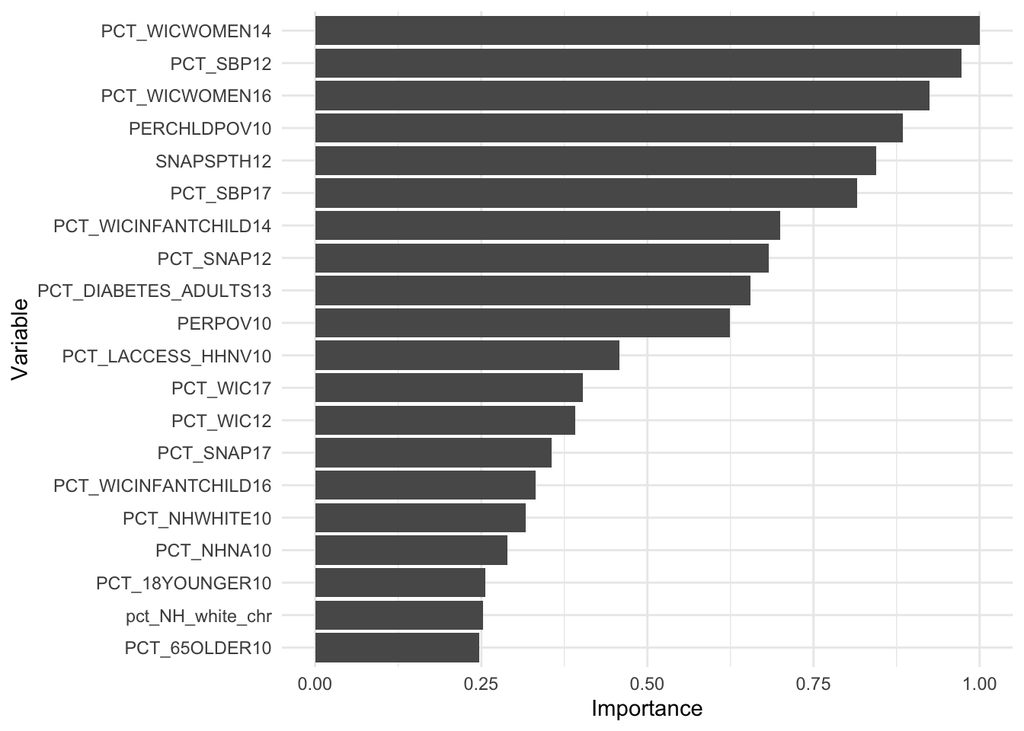

```r
final_fit_rf |>
  extract_fit_parsnip() |>
  vip(num_features = 20) %>%
  .$data |>
  mutate(
    Importance = Importance / max(Importance),
    Variable = fct_reorder(.x = Importance, .f = Variable)
  ) |>
  ggplot(aes(Importance, Variable)) +
  geom_col() +
  theme_minimal()
```

For simplicity, we will apply a calculator to one of the most important predictors, participation of women in WIC, a food assistance program targeted toward new mothers and infants in need of supplemental nutrition assistance. The program provides staple foods to mothers and children who meet nutritional risk criteria. Modeling increased participation in the WIC program can give us an idea of how a change to this policy may affect food insecurity rates in counties in the United States.

#### Creating a Calculator to Change WIC Policy

The following function models a change in women participating in the WIC program. We targeted the simulation to change participation in WIC for counties with persistent childhood poverty, which is another important predictor of food insecurity identified by our random forest model.

```r
#' WIC Participation Change
#'
#' @param child_pov # Variable representing persistent child poverty in counties, in this case "PERCHLDPOV10"
#' @param wic_part # Original participation rate of women in WIC, in this case "PCT_WICWOMEN16"
#' @param wic_part_change # Change in participation to model. Can be any positive or negative integer.
#'
#' @return
#' @export
#'
#' @examples
#' Example: Modeling a 10% increase in % of women participating in WIC
#' WIC_10 <- atlas_chr_snap %>%
 # mutate(PCT_WICWOMEN16 =
       #  WIC_participation_change(
       #    child_pov = PERCHLDPOV10,
       #      wic_part = PCT_WICWOMEN16,
       #      wic_part_change = 20))

WIC_participation_change <- function(child_pov, wic_part, wic_part_change) {

  change <- dplyr::case_when(
    child_pov == 1 ~ wic_part + (wic_part_change),  # Increase by 20 for counties with persistent child poverty

    TRUE ~ wic_part  # Retain the original value for counties without persistent child poverty
  )
  return(change)
}
```

We then apply the function to model an increase in WIC participation and a decrease in WIC participation, and compare the changes in food insecurity as a result. To do this, we apply our calculator to our original dataset to change WIC participation rates, and then predict new food insecurity levels using our trained random forest model. This provides an approximation of how food insecurity levels may change if WIC participation increases or decreases.

The following tables show how food insecurity could change with this shift in WIC participation, across 10 population deciles of counties.

### Modeling an Increase in WIC Participation

The following output is a summary of the predicted values of food insecurity with a 20% increase in womens’ participation in the WIC program.

```r
WIC_10 <- atlas_chr_snap %>%
  mutate(PCT_WICWOMEN16 =
           WIC_participation_change(
             child_pov = PERCHLDPOV10,
             wic_part = PCT_WICWOMEN16,
             wic_part_change = 20))  %>%
  select(-food_insecurity_chr)


# Extract the workflow from final_fit
rf_workflow <- extract_workflow(final_fit_rf)

# Predict food insecurity using the random forest model with the new WIC participation variable
predicted_food_insecurity <- predict(rf_workflow, new_data = WIC_10)

change_plus_10 <- cbind(predicted_food_insecurity, atlas_chr_snap$food_insecurity_chr, atlas_chr_snap) %>%
    rename("food_insecurity_original" = "atlas_chr_snap$food_insecurity_chr")

change_plus_10 <- change_plus_10 %>%
  mutate(food_insecurity_change = .pred - food_insecurity_original)

change_plus_10$.pred %>%
  summary()
```

```
   Min. 1st Qu.  Median    Mean 3rd Qu.    Max.
0.03470 0.09299 0.11298 0.11492 0.13580 0.22478
```

```r
change_plus_10$food_insecurity_original %>%
  summary()
```

```
   Min. 1st Qu.  Median    Mean 3rd Qu.    Max.
 0.0220  0.0890  0.1120  0.1146  0.1375  0.2550
```

In comparison with the summary of food insecurity at original levels, we can see that an increase in WIC participation may be associated with a slight increase in food insecurity, as average food insecurity is slightly higher with the participation change.

```r
dist_table_increase <- change_plus_10 %>%
  mutate(pop_decile = ntile(Population_Estimate_2018, n = 10)) %>%
  group_by(pop_decile) %>%
  summarize(
    min_pop = min(Population_Estimate_2018),
    max_pop = max(Population_Estimate_2018),
    mean_food_insecurity = mean(.pred)
  )

dist_table_increase
```

```
# A tibble: 10 × 4
   pop_decile min_pop  max_pop mean_food_insecurity
        <int>   <dbl>    <dbl>                <dbl>
 1          1      88     5039               0.107
 2          2    5058     8810               0.119
 3          3    8812    13397               0.125
 4          4   13401    18794               0.122
 5          5   18804    25825               0.125
 6          6   25832    36803               0.119
 7          7   36804    53745               0.118
 8          8   53889    94324               0.114
 9          9   94340   213413               0.103
10         10  215707 10105518               0.0969
```

The above distribution table demonstrates how average food insecurity is distributed across 10 different levels of population in counties; this table will be used later to create a visualization comparing changes in participation.

### Modeling a Decrease in WIC Participation

The following output is a summary of food insecurity when womens’ participation in WIC decreases by 20%. As we can see, average food insecurity decreases in comparison to original levels of participation, from approximately 0.1146 to 0.1137.

```r
# Predicting food insecurity with a minus 10 percent WIC participation
WIC_minus_10 <- atlas_chr_snap %>%
  mutate(PCT_WICWOMEN16 =
           WIC_participation_change(
             child_pov = PERCHLDPOV10,
             wic_part = PCT_WICWOMEN16,
             wic_part_change = -20
             ))  %>%
  select(-food_insecurity_chr)

food_insecurity_minus_10 <- predict(rf_workflow, new_data = WIC_minus_10)

change_minus_10 <- cbind(food_insecurity_minus_10, atlas_chr_snap$food_insecurity_chr, atlas_chr_snap) %>%
    rename("food_insecurity_original" = "atlas_chr_snap$food_insecurity_chr")

change_minus_10 <- change_minus_10 %>%
  mutate(food_insecurity_change = .pred - food_insecurity_original)

change_minus_10$.pred %>%
  summary()
```

```
   Min. 1st Qu.  Median    Mean 3rd Qu.    Max.
0.03470 0.09293 0.11274 0.11368 0.13433 0.21671
```

```r
dist_table_decrease <- change_minus_10 %>%
  mutate(pop_decile = ntile(Population_Estimate_2018, n = 10)) %>%
  group_by(pop_decile) %>%
  summarize(
    min_pop = min(Population_Estimate_2018),
    max_pop = max(Population_Estimate_2018),
    mean_food_insecurity = mean(.pred)
  )
dist_table_decrease
```

```
# A tibble: 10 × 4
   pop_decile min_pop  max_pop mean_food_insecurity
        <int>   <dbl>    <dbl>                <dbl>
 1          1      88     5039               0.106
 2          2    5058     8810               0.117
 3          3    8812    13397               0.123
 4          4   13401    18794               0.120
 5          5   18804    25825               0.123
 6          6   25832    36803               0.118
 7          7   36804    53745               0.117
 8          8   53889    94324               0.113
 9          9   94340   213413               0.103
10         10  215707 10105518               0.0963
```

Once again, this distribution table shows average food insecurity across population deciles with a decrease in WIC participation. This will be used to visualize the difference in participation below.

### Modeling Original WIC Participation

```r
# Modeling original level of participation
dist_table_original <- change_minus_10 %>%
  mutate(pop_decile = ntile(Population_Estimate_2018, n = 10)) %>%
  group_by(pop_decile) %>%
  summarize(
    mean_food_insecurity = mean(food_insecurity_original),
    min_pop = min(Population_Estimate_2018),
    max_pop = max(Population_Estimate_2018))


dist_table_original
```

```
# A tibble: 10 × 4
   pop_decile mean_food_insecurity min_pop  max_pop
        <int>                <dbl>   <dbl>    <dbl>
 1          1               0.106       88     5039
 2          2               0.119     5058     8810
 3          3               0.125     8812    13397
 4          4               0.122    13401    18794
 5          5               0.125    18804    25825
 6          6               0.119    25832    36803
 7          7               0.117    36804    53745
 8          8               0.114    53889    94324
 9          9               0.104    94340   213413
10         10               0.0966  215707 10105518
```

### Visualizing Distribution of Food Insecurity after WIC Participation Change

Lastly, we visualize this change in food insecurity with a line plot. While the change is incremental, it is clear that WIC participation has a relationship with food insecurity levels in counties, and the strength of this relationship varies across population levels of counties.

It appears that a decrease in WIC participation is associated with overall lower levels of food insecurity, across varying population levels. This makes sense if we consider the fact that increased WIC participation is likely correlated with higher levels of food insecurity. An increase in WIC participation is associated with a very slight increase in food insecurity, in the population deciles 6-8. The change is minimal in comparison to a decrease in WIC participation, however.

The nature of the WIC program is evident in our line plot. The program is designed for mothers and infants who are in significant need of extra assistance for food, so it makes sense that the counties with higher food insecurity levels would have higher WIC participation rates. This simulation demonstrates the importance of the WIC program to counties with high levels of food insecurity, and can inform policy decisions around this and other food assistance programs.

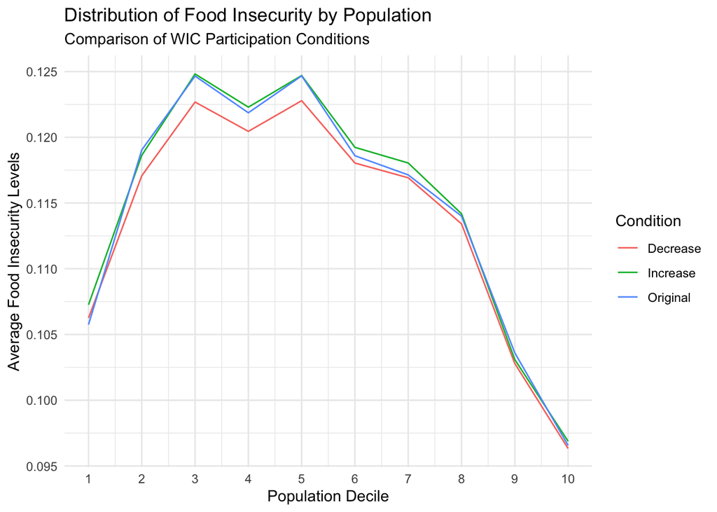

```r
# Combine the data frames
combined_data <- rbind(
  transform(dist_table_original, Condition = "Original"),
  transform(dist_table_increase, Condition = "Increase"),
  transform(dist_table_decrease, Condition = "Decrease")
)

# Plot
combined_plot <- ggplot(combined_data, aes(x = pop_decile, y = mean_food_insecurity, color = Condition)) +
  geom_line() +
  scale_x_continuous(breaks = 1:10) +
  labs(
    title = "Distribution of Food Insecurity by Population",
    subtitle = "Comparison of WIC Participation Conditions",
    x = "Population Decile",
    y = "Average Food Insecurity Levels"
  ) +
  theme_minimal()

# Display the plot
print(combined_plot)
```

### Conclusion

In our project we set out to create a predictive model that reliably predicts food insecurity levels in counties based on sociodemographic and policy characteristics. While we were unable to actually apply the model to implementation data, it seems that it performs reliably on unseen data.

This model could be used to predict food insecurity levels in response to policy or environmental changes, such as participation in certain government programs. We modeled a change in WIC participation using one of our predictive models, and found that we could predict how food insecurity may change in response to changes in behavior.

While this can be very useful in policy applications, the simulation model was quite simple– it is clear that policy expertise is needed to understand exactly how program participation would change in order to increase the accuracy of predictions.

In conclusion, our predictive models and simulation provide a helpful view into how county-level characteristics and food policies can affect food insecurity. Our simulation, informed by policy and behavioral expertise can be helpful in predicting how food insecurity may change due to policy or environmental changes.

## References

Bartfeld, Judi, and Rachel Dunifon. 2006. “State-Level Predictors of Food Insecurity Among Households with Children.” *Journal of Policy Analysis and Management* 25 (4): 921–42. https://doi.org/10.1002/pam.20214.

Hake, Monica, Emily Engelhard, and Adam Dewey. 2023. “Map the Meal Gap 2023.” https://www.feedingamerica.org/research/map-the-meal-gap/overall-executive-summary.

Hunt, Bijou R., Maureen R. Benjamins, Sabena Khan, and Jana L. Hirschtick. 2019. “Predictors of Food Insecurity in Selected Chicago Community Areas.” *Journal of Nutrition Education and Behavior* 51 (3): 287–99. https://doi.org/10.1016/j.jneb.2018.08.005.

Nicklett, Emily Joy, Greta Jianjia Cheng, and Zachary A. Morris. 2023. “Predictors of Food Insecurity Among Older Adults Before and During COVID-19 in the United States.” *Frontiers in Public Health* 11 (May). https://doi.org/10.3389/fpubh.2023.1112575.

Rabbitt, Matthew P., Laura J. Hales, Michael P. Burke, and Alisha Coleman-Jensen. n.d. “Household Food Security in the United States in 2022.” http://www.ers.usda.gov/publications/pub-details/?pubid=107702.